# Practicum Activity: EDA and Predictive Modeling on the Pima Indians Diabetes Dataset

Practicum 1 - TOTD 2026/27

Your Team C - L1 / Oriol Arasa, Izan Flores, Andreu Jordà, Jordi Vivas

2026-10-14

# 1 Overview

In this practicum, you will work with the **Pima Indians Diabetes Dataset** (Kaggle: `uciml/pima-indians-diabetes-database`) to practice the full data analysis pipeline: exploration, cleaning, visualization, and predictive modeling. The dataset contains diagnostic measurements for female patients of Pima Indian heritage, aged 21 and older, and a binary outcome indicating whether the patient has diabetes.

**Estimated time:** 2–3 hours **Deliverable:** This completed `.Rmd` file, knitted to HTML, with all code chunks filled in and all reflection questions answered in the text.

## 1.1 Learning Objectives

By the end of this activity, you should be able to:

1. Load, inspect, and clean a real-world tabular dataset in R
2. Identify and handle implausible or missing values disguised as valid entries
3. Perform univariate and bivariate exploratory data analysis (EDA)
4. Visualize relationships between features and a binary outcome
5. Build and evaluate at least one classification model
6. Communicate findings and limitations, including ethical considerations around health data

## 1.2 Dataset Description

| Column | Description |
| --- | --- |
| `Pregnancies` | Number of times pregnant |
| `Glucose` | Plasma glucose concentration (2-hr oral glucose tolerance test) |
| `BloodPressure` | Diastolic blood pressure (mm Hg) |
| `SkinThickness` | Triceps skinfold thickness (mm) |
| `Insulin` | 2-hr serum insulin (mu U/ml) |
| `BMI` | Body mass index |
| `DiabetesPedigreeFunction` | Score of diabetes likelihood based on family history |
| `Age` | Age in years |
| `Outcome` | 0 = no diabetes, 1 = diabetes |

# 2 Part 1: Data Loading and Initial Inspection

```r
# TODO: update the path to wherever you saved diabetes.csv after downloading from Kaggle
diabetes <- read_csv("diabetes.csv")

# Inspect structure
glimpse(diabetes)
```

```
## Rows: 768
## Columns: 9
## $ Pregnancies              <dbl> 6, 1, 8, 1, 0, 5, 3, 10, 2, 8, 4, 10, 10, 1, …
## $ Glucose                  <dbl> 148, 85, 183, 89, 137, 116, 78, 115, 197, 125…
## $ BloodPressure            <dbl> 72, 66, 64, 66, 40, 74, 50, 0, 70, 96, 92, 74…
## $ SkinThickness            <dbl> 35, 29, 0, 23, 35, 0, 32, 0, 45, 0, 0, 0, 0, …
## $ Insulin                  <dbl> 0, 0, 0, 94, 168, 0, 88, 0, 543, 0, 0, 0, 0, …
## $ BMI                      <dbl> 33.6, 26.6, 23.3, 28.1, 43.1, 25.6, 31.0, 35.…
## $ DiabetesPedigreeFunction <dbl> 0.627, 0.351, 0.672, 0.167, 2.288, 0.201, 0.2…
## $ Age                      <dbl> 50, 31, 32, 21, 33, 30, 26, 29, 53, 54, 30, 3…
## $ Outcome                  <dbl> 1, 0, 1, 0, 1, 0, 1, 0, 1, 1, 0, 1, 0, 1, 1, …
```

```r
summary(diabetes)
```

```
##   Pregnancies        Glucose      BloodPressure    SkinThickness
##  Min.   : 0.000   Min.   :  0.0   Min.   :  0.00   Min.   : 0.00
##  1st Qu.: 1.000   1st Qu.: 99.0   1st Qu.: 62.00   1st Qu.: 0.00
##  Median : 3.000   Median :117.0   Median : 72.00   Median :23.00
##  Mean   : 3.845   Mean   :120.9   Mean   : 69.11   Mean   :20.54
##  3rd Qu.: 6.000   3rd Qu.:140.2   3rd Qu.: 80.00   3rd Qu.:32.00
##  Max.   :17.000   Max.   :199.0   Max.   :122.00   Max.   :99.00
##     Insulin           BMI        DiabetesPedigreeFunction      Age
##  Min.   :  0.0   Min.   : 0.00   Min.   :0.0780           Min.   :21.00
##  1st Qu.:  0.0   1st Qu.:27.30   1st Qu.:0.2437           1st Qu.:24.00
##  Median : 30.5   Median :32.00   Median :0.3725           Median :29.00
##  Mean   : 79.8   Mean   :31.99   Mean   :0.4719           Mean   :33.24
##  3rd Qu.:127.2   3rd Qu.:36.60   3rd Qu.:0.6262           3rd Qu.:41.00
##  Max.   :846.0   Max.   :67.10   Max.   :2.4200           Max.   :81.00
##     Outcome
##  Min.   :0.000
##  1st Qu.:0.000
##  Median :0.000
##  Mean   :0.349
##  3rd Qu.:1.000
##  Max.   :1.000
```

```r
diabetes |>
  count(Outcome) |>
  mutate(proportion = n / sum(n))
```

```
## # A tibble: 2 × 3
##   Outcome     n proportion
##     <dbl> <int>      <dbl>
## 1       0   500      0.651
## 2       1   268      0.349
```

**Reflection question:** Based on the summary statistics alone, do you notice anything suspicious about the minimum values of certain columns (e.g., `Glucose`, `BloodPressure`, `BMI`, `SkinThickness`, `Insulin`)?

> *When we do the summary we can see in some variables minimums of 0 when the variable can’t be 0. The ones that can’t be that we see are Glucose, Blood pressure, Skin Thickness, Insulin and BMI.*

# 3 Part 2: Data Cleaning

Several columns use `0` to represent missing data, which is not physiologically plausible (e.g., blood pressure of 0).

```r
zero_cols <- c("Glucose", "BloodPressure", "SkinThickness", "Insulin", "BMI")

diabetes |>
  summarise(across(all_of(zero_cols), ~ sum(. == 0)))
```

```
## # A tibble: 1 × 5
##   Glucose BloodPressure SkinThickness Insulin   BMI
##     <int>         <int>         <int>   <int> <int>
## 1       5            35           227     374    11
```

```r
# Replace implausible zeros with NA
diabetes_clean <- diabetes |>
  mutate(across(all_of(zero_cols), ~ na_if(., 0)))

# DONE: Impute missing values. Example: median imputation stratified by Outcome
diabetes_clean <- diabetes_clean |>
  group_by(Outcome) |>
  mutate(across(all_of(zero_cols), ~ ifelse(is.na(.), median(., na.rm = TRUE), .))) |>
  ungroup()

# Verify no missing values remain
colSums(is.na(diabetes_clean))
```

```
##              Pregnancies                  Glucose            BloodPressure
##                        0                        0                        0
##            SkinThickness                  Insulin                      BMI
##                        0                        0                        0
## DiabetesPedigreeFunction                      Age                  Outcome
##                        0                        0                        0
```

**Reflection question:** Why might imputing missing values *within each Outcome group* separately be more appropriate than imputing across the whole dataset?

> *Because there may be groups that can have a value of zero in some mesures.*

# 4 Part 3: Exploratory Data Analysis

## 4.1 Univariate analysis

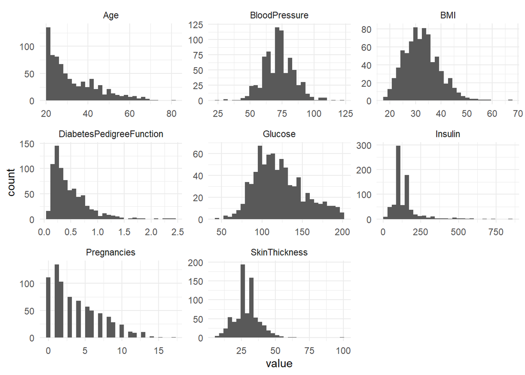

```r
diabetes_clean |>
  pivot_longer(-Outcome, names_to = "feature", values_to = "value") |>
  ggplot(aes(x = value)) +
  geom_histogram(bins = 30) +
  facet_wrap(~ feature, scales = "free") +
  theme_minimal()
```

## 4.2 Bivariate analysis

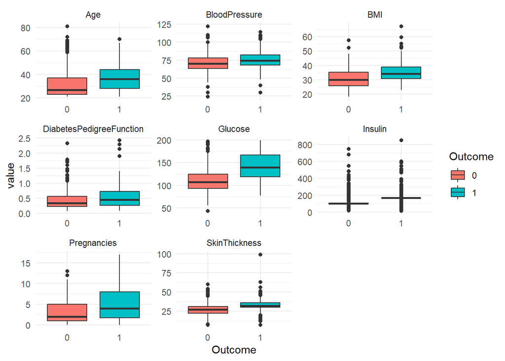

```r
diabetes_clean |>
  mutate(Outcome = factor(Outcome)) |>
  pivot_longer(-Outcome, names_to = "feature", values_to = "value") |>
  ggplot(aes(x = Outcome, y = value, fill = Outcome)) +
  geom_boxplot() +
  facet_wrap(~ feature, scales = "free") +
  theme_minimal()
```

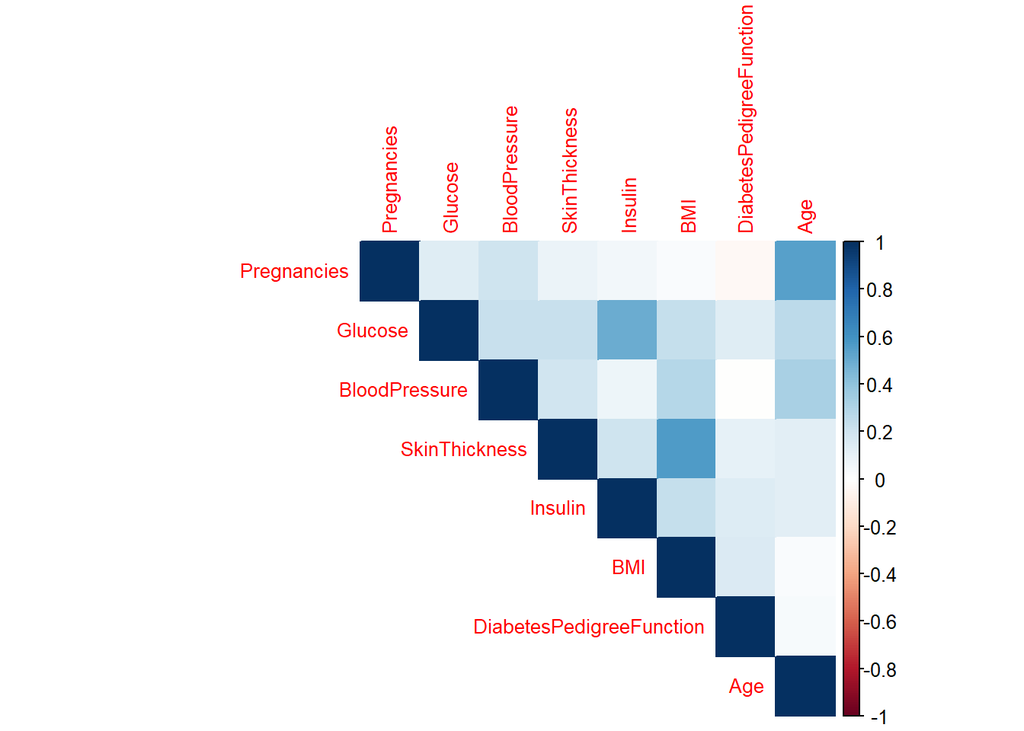

```r
corr_matrix <- cor(diabetes_clean |> select(-Outcome))
corrplot(corr_matrix, method = "color", type = "upper", tl.cex = 0.8)
```

**Reflection question:** Does `Glucose` show a strong visual separation between the two outcome groups? What does this suggest about its predictive value?